# Classifying Mushrooms

The goal of this project is to identify mushrooms that are edible or are poisonous based on various physical features of the mushroom. The original dataset can be obtained here:

- [Mushrooms Dataset](https://www.kaggle.com/uciml/mushroom-classification)

# Exploring and Preparing the Data

```r
# Importing the dataset and libraries
mushrooms <- read.csv("mushrooms.csv", stringsAsFactors = TRUE, na.strings = "?")
```

The dataset is comprised of 23 variables of 8124 observations. All the variables are categorical. Each variable is comprised of different letters representing a shortened version of the feature name. The class variable consists of 2 levels, e = edible and p = poisonous.

```r
# Summary of the dataset
str(mushrooms)
```

```
'data.frame':   8124 obs. of  23 variables:
 $ class                   : Factor w/ 2 levels "e","p": 2 1 1 2 1 1 1 1 2 1 ...
 $ cap.shape               : Factor w/ 6 levels "b","c","f","k",..: 6 6 1 6 6 6 1 1 6 1 ...
 $ cap.surface             : Factor w/ 4 levels "f","g","s","y": 3 3 3 4 3 4 3 4 4 3 ...
 $ cap.color               : Factor w/ 10 levels "b","c","e","g",..: 5 10 9 9 4 10 9 9 9 10 ...
 $ bruises                 : Factor w/ 2 levels "f","t": 2 2 2 2 1 2 2 2 2 2 ...
 $ odor                    : Factor w/ 9 levels "a","c","f","l",..: 7 1 4 7 6 1 1 4 7 1 ...
 $ gill.attachment         : Factor w/ 2 levels "a","f": 2 2 2 2 2 2 2 2 2 2 ...
 $ gill.spacing            : Factor w/ 2 levels "c","w": 1 1 1 1 2 1 1 1 1 1 ...
 $ gill.size               : Factor w/ 2 levels "b","n": 2 1 1 2 1 1 1 1 2 1 ...
 $ gill.color              : Factor w/ 12 levels "b","e","g","h",..: 5 5 6 6 5 6 3 6 8 3 ...
 $ stalk.shape             : Factor w/ 2 levels "e","t": 1 1 1 1 2 1 1 1 1 1 ...
 $ stalk.root              : Factor w/ 4 levels "b","c","e","r": 3 2 2 3 3 2 2 2 3 2 ...
 $ stalk.surface.above.ring: Factor w/ 4 levels "f","k","s","y": 3 3 3 3 3 3 3 3 3 3 ...
 $ stalk.surface.below.ring: Factor w/ 4 levels "f","k","s","y": 3 3 3 3 3 3 3 3 3 3 ...
 $ stalk.color.above.ring  : Factor w/ 9 levels "b","c","e","g",..: 8 8 8 8 8 8 8 8 8 8 ...
 $ stalk.color.below.ring  : Factor w/ 9 levels "b","c","e","g",..: 8 8 8 8 8 8 8 8 8 8 ...
 $ veil.type               : Factor w/ 1 level "p": 1 1 1 1 1 1 1 1 1 1 ...
 $ veil.color              : Factor w/ 4 levels "n","o","w","y": 3 3 3 3 3 3 3 3 3 3 ...
 $ ring.number             : Factor w/ 3 levels "n","o","t": 2 2 2 2 2 2 2 2 2 2 ...
 $ ring.type               : Factor w/ 5 levels "e","f","l","n",..: 5 5 5 5 1 5 5 5 5 5 ...
 $ spore.print.color       : Factor w/ 9 levels "b","h","k","n",..: 3 4 4 3 4 3 3 4 3 3 ...
 $ population              : Factor w/ 6 levels "a","c","n","s",..: 4 3 3 4 1 3 3 4 5 4 ...
 $ habitat                 : Factor w/ 7 levels "d","g","l","m",..: 6 2 4 6 2 2 4 4 2 4 ...
```

## Data Cleaning

The variable **stalk.root** contains “?” which indicates a missing value. We will update that to NA. None of the other variables are missing data. The **stalk.root** variable is missing ~30.5% of its data. Removing those rows will put quite a dent in the information and so we will impute the data later using MICE

```r
100 * length(which(!complete.cases(mushrooms$stalk.root))) / length(complete.cases(mushrooms$stalk.root))
```

```
[1] 30.52683
```

```r
colSums(is.na(mushrooms))
```

```
                   class                cap.shape              cap.surface                cap.color                  bruises
                       0                        0                        0                        0                        0
                    odor          gill.attachment             gill.spacing                gill.size               gill.color
                       0                        0                        0                        0                        0
             stalk.shape               stalk.root stalk.surface.above.ring stalk.surface.below.ring   stalk.color.above.ring
                       0                     2480                        0                        0                        0
  stalk.color.below.ring                veil.type               veil.color              ring.number                ring.type
                       0                        0                        0                        0                        0
       spore.print.color               population                  habitat
                       0                        0                        0
```

```r
prop.table(table(mushrooms$stalk.root, exclude = NULL))
```

```
         b          c          e          r       <NA>
0.46479567 0.06843919 0.13786312 0.02363368 0.30526834
```

We will replace the letter representations of the variables by the actual word to better understand what features are being measured.

```r
levels(mushrooms$class) <- c(e="edible", p="poisonous")
levels(mushrooms$cap.shape) <- c(b="bell", c="conical", f="flat", k="knobbed", s="sunken", x="convex")
levels(mushrooms$cap.surface) <- c(f="fibrous", g="grooves", s="smooth", y="scaly")
levels(mushrooms$cap.color) <- c(n="brown", b="buff", c="cinnamon", g="gray", r="green", p="pink", u="purple", e="red", w="white", y="yellow")
levels(mushrooms$bruises) <- c(t="true", f="false")
levels(mushrooms$odor) <- c(a="almond", l="anise", c="creosote", y="fishy", f="foul", m="musty", n="none", p="pungent", s="spicy")
levels(mushrooms$gill.attachment) <- c(a="attached", f="free")
levels(mushrooms$gill.spacing) <- c(c="close", w="crowded")
levels(mushrooms$gill.size) <- c(b="broad", n="narrow")
levels(mushrooms$gill.color) <- c(b="buff", e="red", g="gray", h="chocolate", k="black", n="brown", r="green", o="orange", p="pink", u="purple", w="white", y="yellow")
levels(mushrooms$stalk.shape) <- c(e="enlarging", t="tapering")
levels(mushrooms$stalk.root) <- c(b="bulbous", c="club", e="equal", r="rooted")
levels(mushrooms$stalk.surface.above.ring) <- c(f="fibrous", y="scaly", k="silky", s="smooth")
levels(mushrooms$stalk.surface.below.ring) <- c(f="fibrous", y="scaly", k="silky", s="smooth")
levels(mushrooms$stalk.color.above.ring) <- c(n="brown", b="buff", c="cinnamon", g="gray", o="orange", p="pink", e="red", w="white", y="yellow")
levels(mushrooms$stalk.color.below.ring) <- c(n="brown", b="buff", c="cinnamon", g="gray", o="orange", p="pink", e="red", w="white", y="yellow")
levels(mushrooms$veil.color) <- c(n="brown", o="orange", w="white", y="yellow")
levels(mushrooms$ring.number) <- c(n="none", o="one", t="two")
levels(mushrooms$ring.type) <- c(c="cobwebby", e="evanescent", f="flaring", l="large", n="none", p="pendant", s="sheathing", z="zone")
levels(mushrooms$spore.print.color) <- c(k="black", n="brown", b="buff", h="chocolate", r="green", o="orange", u="purple", w="white", y="yellow")
levels(mushrooms$population) <- c(a="abundant", c="clustered", n="numerous", s="scattered", v="several", y="solitary")
levels(mushrooms$habitat) <- c(g="grasses", l="leaves", m="meadows", p="paths", u="urban", w="waste", d="woods")
```

The variable **veil.type** only consists of a single level which will not contribute to the models and will be removed.

```r
mushrooms$veil.type <- NULL
```

## Data Visualization

Let us first visualize the class variable to see if there is a majority classifier. It does not appear that one category outweighs the other.

```r
library(ggplot2)
prop.table(table(mushrooms$class))
```

```
   edible poisonous
0.5179714 0.4820286
```

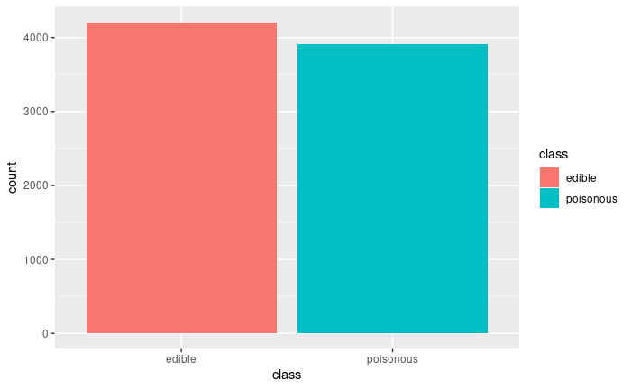

```r
ggplot(mushrooms, aes(class, ..count..)) + geom_bar(aes(fill=class), position="dodge")
```

Let us examine the features with the class variable to check for any associations.

### Class and Cap Properties

The Chi-squared test returned a p-value less than a significance level of 0.05 for all three properties of the cap. The graph’s point out some interesting properties about each class of mushrooms. In the cap shape graph the poisonous mushrooms have more knobbed shapes while edible have more bell shaped. In the cap surface graph there is about a 1000 count difference in fibrous surfaces in edible mushrooms than in poisonous ones. The cap color also shows that more poisonous mushrooms are yellow or cinnamon while edible mushrooms tend to be white, gray, or green.

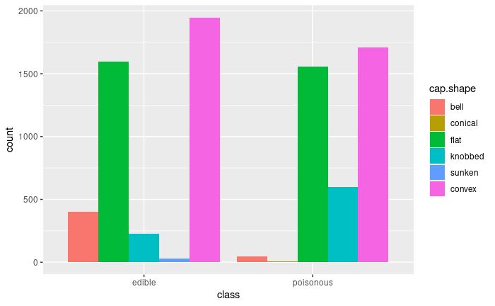

```r
# Cap Shape
ggplot(mushrooms, aes(class, ..count..)) + geom_bar(aes(fill=cap.shape), position="dodge")
```

```r
chisq.test(mushrooms$class, mushrooms$cap.shape)
```

```
Chi-squared approximation may be incorrect
```

```
    Pearson's Chi-squared test

data:  mushrooms$class and mushrooms$cap.shape
X-squared = 489.92, df = 5, p-value < 2.2e-16
```

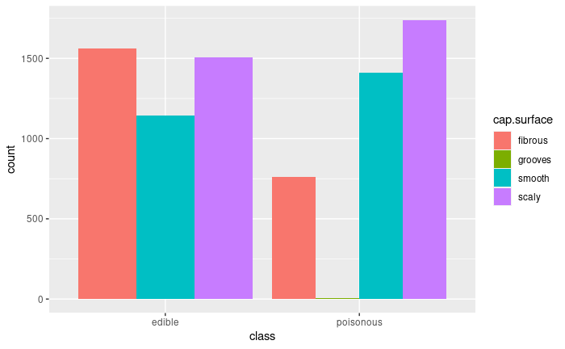

```r
# Cap Surface
ggplot(mushrooms, aes(class, ..count..)) + geom_bar(aes(fill=cap.surface), position="dodge")
```

```r
chisq.test(mushrooms$class, mushrooms$cap.surface)
```

```
Chi-squared approximation may be incorrect
```

```
    Pearson's Chi-squared test

data:  mushrooms$class and mushrooms$cap.surface
X-squared = 315.04, df = 3, p-value < 2.2e-16
```

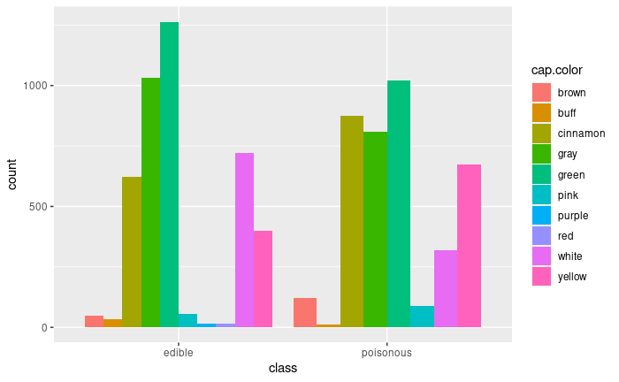

```r
# Cap Color
ggplot(mushrooms, aes(class, ..count..)) + geom_bar(aes(fill=cap.color), position="dodge")
```

```r
chisq.test(mushrooms$class, mushrooms$cap.color)
```

```
    Pearson's Chi-squared test

data:  mushrooms$class and mushrooms$cap.color
X-squared = 387.6, df = 9, p-value < 2.2e-16
```

### Class and Bruises

The Chi-squared test returned a p-value less than a significance level of 0.05 indicating the two variables are associated. The graph also highlights the fact that the poisonous mushrooms have more bruising than the edible mushrooms. Bruising occurs when certain compounds in the cell walls of the mushroom are exposed to the air. More information can be found here:

- [Identifying Mushrooms Through Bruising and Bleeding](https://www.mushroom-appreciation.com/identifying-mushrooms.html)

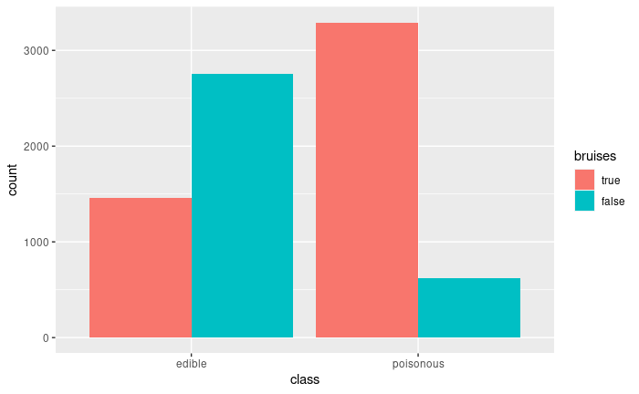

```r
ggplot(mushrooms, aes(class, ..count..)) + geom_bar(aes(fill=bruises), position="dodge")
```

```r
chisq.test(mushrooms$class, mushrooms$bruises)
```

```
    Pearson's Chi-squared test with Yates' continuity correction

data:  mushrooms$class and mushrooms$bruises
X-squared = 2041.4, df = 1, p-value < 2.2e-16
```

### Class and Odor

The Chi-squared test returned a p-value less than a significance level of 0.05 indicating the two variables are associated. The graph also highlights the fact that poisonous mushrooms have more variety of smells with creosote being the most common, while edible mushrooms mostly have a musty smell to them.

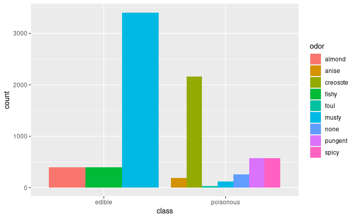

```r
ggplot(mushrooms, aes(class, ..count..)) + geom_bar(aes(fill=odor), position="dodge")
```

```r
chisq.test(mushrooms$class, mushrooms$odor)
```

```
    Pearson's Chi-squared test

data:  mushrooms$class and mushrooms$odor
X-squared = 7659.7, df = 8, p-value < 2.2e-16
```

### Class and Gill Properties

The Chi-squared test returned a p-value less than a significance level of 0.05 for each property. The gill size graph indicated poisonous mushrooms have more narrow gills while edible mushrooms have more broad gills. The gill attachment graph shows that most gills are free for both edible and poisonous mushrooms. Since this variable is almost equal for both classes it will be removed. In the gill color graph poisonous mushrooms have a buff color while none of the edible mushrooms have that color at all

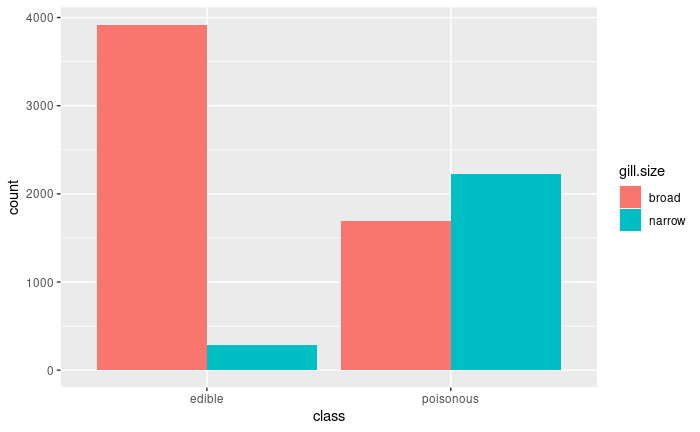

```r
# Gill Size
ggplot(mushrooms, aes(class, ..count..)) + geom_bar(aes(fill=gill.size), position="dodge")
```

```r
chisq.test(mushrooms$class, mushrooms$gill.size)
```

```
    Pearson's Chi-squared test with Yates' continuity correction

data:  mushrooms$class and mushrooms$gill.size
X-squared = 2366.8, df = 1, p-value < 2.2e-16
```

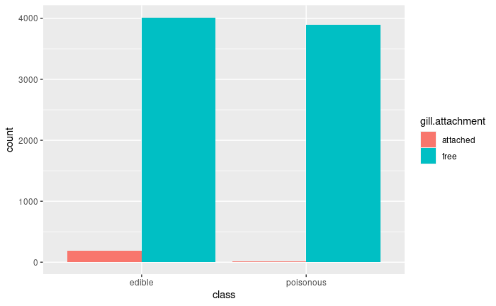

```r
# Gill Attachment
ggplot(mushrooms, aes(class, ..count..)) + geom_bar(aes(fill=gill.attachment), position="dodge")
```

```r
chisq.test(mushrooms$class, mushrooms$gill.attachment)
```

```
    Pearson's Chi-squared test with Yates' continuity correction

data:  mushrooms$class and mushrooms$gill.attachment
X-squared = 133.99, df = 1, p-value < 2.2e-16
```

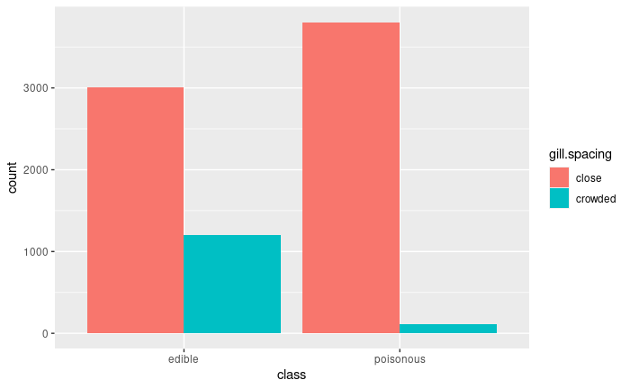

```r
mushrooms$gill.attachment <- NULL
# Gill Spacing
ggplot(mushrooms, aes(class, ..count..)) + geom_bar(aes(fill=gill.spacing), position="dodge")
```

```r
chisq.test(mushrooms$class, mushrooms$gill.spacing)
```

```
    Pearson's Chi-squared test with Yates' continuity correction

data:  mushrooms$class and mushrooms$gill.spacing
X-squared = 984.14, df = 1, p-value < 2.2e-16
```

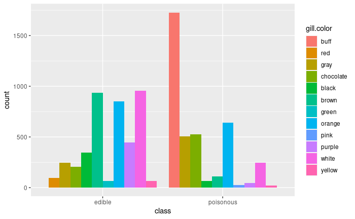

```r
# Gill Color
ggplot(mushrooms, aes(class, ..count..)) + geom_bar(aes(fill=gill.color), position="dodge")
```

```r
chisq.test(mushrooms$class, mushrooms$gill.color)
```

```
    Pearson's Chi-squared test

data:  mushrooms$class and mushrooms$gill.color
X-squared = 3765.7, df = 11, p-value < 2.2e-16
```

### Class and Stalk Properties

Visualizing the stalk root which contains the large amount of missing data, we can see that both edible and poisonous mushrooms are missing data. We will use the mice function to impute the data and fill in the missing data. Looking at the graphs involving the stalk surface and color it appears that we can combine some of the lower count levels into a single level.

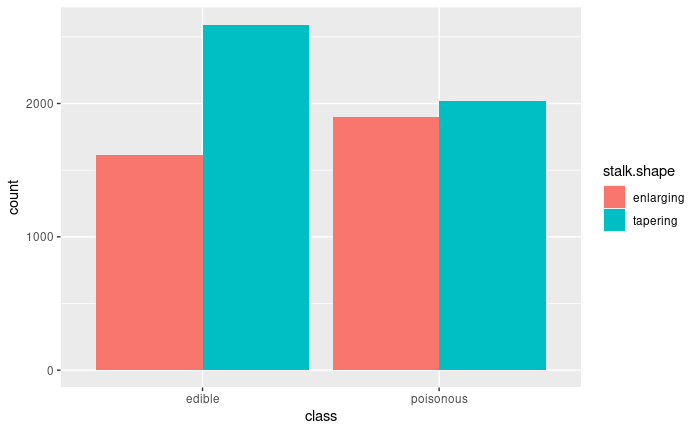

```r
# Stalk Shape
ggplot(mushrooms, aes(class, ..count..)) + geom_bar(aes(fill=stalk.shape), position="dodge")
```

```r
chisq.test(mushrooms$class, mushrooms$stalk.shape)
```

```
    Pearson's Chi-squared test with Yates' continuity correction

data:  mushrooms$class and mushrooms$stalk.shape
X-squared = 84.142, df = 1, p-value < 2.2e-16
```

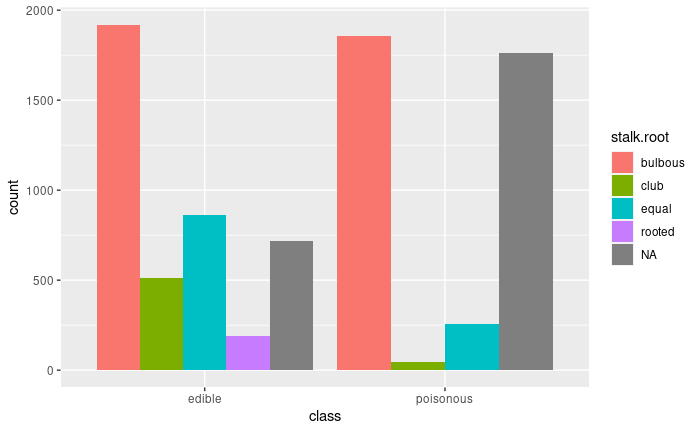

```r
# Stalk Root
ggplot(mushrooms, aes(class, ..count..)) + geom_bar(aes(fill=stalk.root), position="dodge")
```

```r
chisq.test(mushrooms$class, mushrooms$stalk.root)
```

```
    Pearson's Chi-squared test

data:  mushrooms$class and mushrooms$stalk.root
X-squared = 638.26, df = 3, p-value < 2.2e-16
```

```r
# Impute Missing Data
library(mice)
mushrooms <- complete(mice(mushrooms, print = FALSE))
```

```
Number of logged events: 25
```

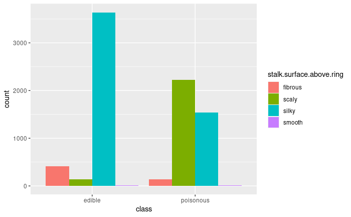

```r
# Stalk Surface Above Ring
ggplot(mushrooms, aes(class, ..count..)) + geom_bar(aes(fill=stalk.surface.above.ring), position="dodge")
```

```r
chisq.test(mushrooms$class, mushrooms$stalk.surface.above.ring)
```

```
    Pearson's Chi-squared test

data:  mushrooms$class and mushrooms$stalk.surface.above.ring
X-squared = 2808.3, df = 3, p-value < 2.2e-16
```

```r
# Combining Levels
library(rockchalk)
mushrooms$stalk.surface.above.ring <- combineLevels(mushrooms$stalk.surface.above.ring, c("smooth", "fibrous"), "other")
```

```
The original levels fibrous scaly silky smooth
have been replaced by scaly silky other
```

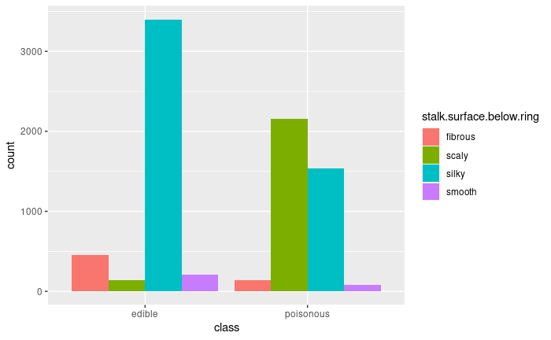

```r
# Stalk Surface Below Ring
ggplot(mushrooms, aes(class, ..count..)) + geom_bar(aes(fill=stalk.surface.below.ring), position="dodge")
```

```r
chisq.test(mushrooms$class, mushrooms$stalk.surface.below.ring)
```

```
    Pearson's Chi-squared test

data:  mushrooms$class and mushrooms$stalk.surface.below.ring
X-squared = 2684.5, df = 3, p-value < 2.2e-16
```

```r
# Combining Levels
mushrooms$stalk.surface.below.ring <- combineLevels(mushrooms$stalk.surface.below.ring, c("smooth", "fibrous"), "other")
```

```
The original levels fibrous scaly silky smooth
have been replaced by scaly silky other
```

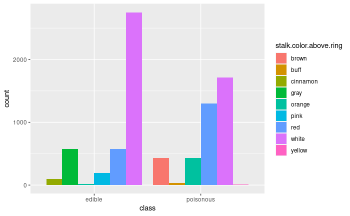

```r
# Stalk Color Above Ring
ggplot(mushrooms, aes(class, ..count..)) + geom_bar(aes(fill=stalk.color.above.ring), position="dodge")
```

```r
chisq.test(mushrooms$class, mushrooms$stalk.color.above.ring)
```

```
Chi-squared approximation may be incorrect
```

```
    Pearson's Chi-squared test

data:  mushrooms$class and mushrooms$stalk.color.above.ring
X-squared = 2237.9, df = 8, p-value < 2.2e-16
```

```r
# Combining Levels
mushrooms$stalk.color.above.ring <- combineLevels(mushrooms$stalk.color.above.ring, c("yellow", "buff", "cinnamon"), "other")
```

```
The original levels brown buff cinnamon gray orange pink red white yellow
have been replaced by brown gray orange pink red white other
```

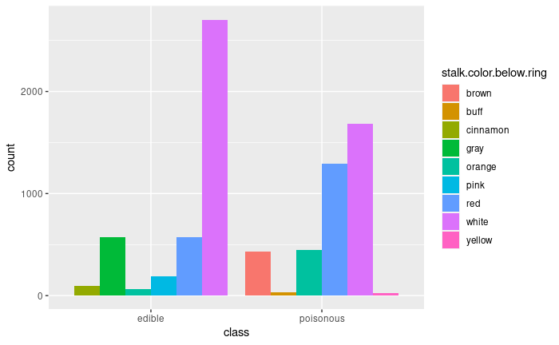

```r
# Stalk Color Below Ring
ggplot(mushrooms, aes(class, ..count..)) + geom_bar(aes(fill=stalk.color.below.ring), position="dodge")
```

```r
chisq.test(mushrooms$class, mushrooms$stalk.color.below.ring)
```

```
    Pearson's Chi-squared test

data:  mushrooms$class and mushrooms$stalk.color.below.ring
X-squared = 2152.4, df = 8, p-value < 2.2e-16
```

```r
# Combining Levels
mushrooms$stalk.color.below.ring <- combineLevels(mushrooms$stalk.color.below.ring, c("yellow", "buff", "cinnamon"), "other")
```

```
The original levels brown buff cinnamon gray orange pink red white yellow
have been replaced by brown gray orange pink red white other
```

### Class and Veil Color

Even though the Chi-Squared test does show a significance between this variable and the class variable. I will remove it since the majority of the data is only in a single color.

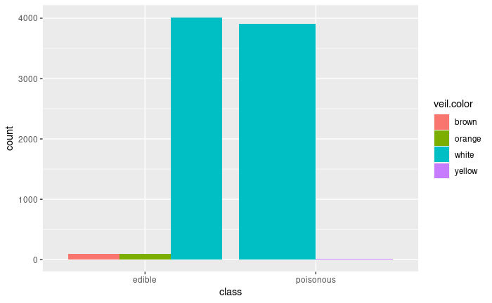

```r
ggplot(mushrooms, aes(class, ..count..)) + geom_bar(aes(fill=veil.color), position="dodge")
```

```r
chisq.test(mushrooms$class, mushrooms$veil.color)
```

```
Chi-squared approximation may be incorrect
```

```
    Pearson's Chi-squared test

data:  mushrooms$class and mushrooms$veil.color
X-squared = 191.22, df = 3, p-value < 2.2e-16
```

```r
mushrooms$veil.color <- NULL
```

### Class and Ring Properties

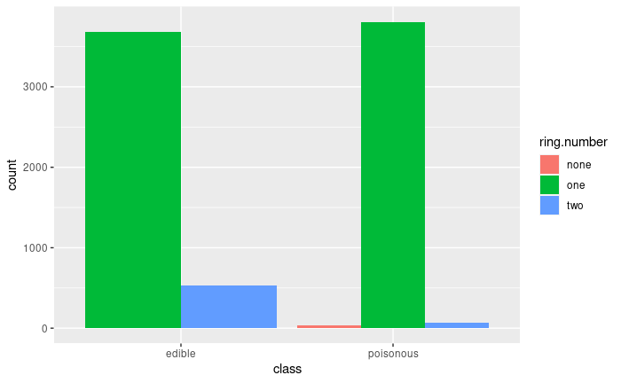

```r
# Ring Number
ggplot(mushrooms, aes(class, ..count..)) + geom_bar(aes(fill=ring.number), position="dodge")
```

```r
chisq.test(mushrooms$class, mushrooms$ring.number)
```

```
    Pearson's Chi-squared test

data:  mushrooms$class and mushrooms$ring.number
X-squared = 374.74, df = 2, p-value < 2.2e-16
```

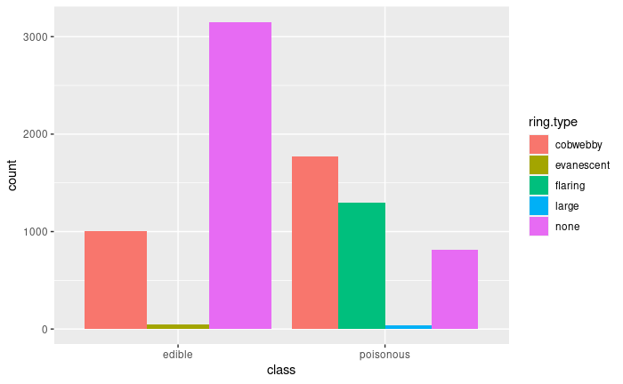

```r
# Ring Type
ggplot(mushrooms, aes(class, ..count..)) + geom_bar(aes(fill=ring.type), position="dodge")
```

```r
chisq.test(mushrooms$class, mushrooms$ring.type)
```

```
    Pearson's Chi-squared test

data:  mushrooms$class and mushrooms$ring.type
X-squared = 2956.6, df = 4, p-value < 2.2e-16
```

```r
# Combining Levels
mushrooms$ring.type <- combineLevels(mushrooms$ring.type, c("large", "evanescent"), "other")
```

[output not shown]

### Class and Spore Print Color

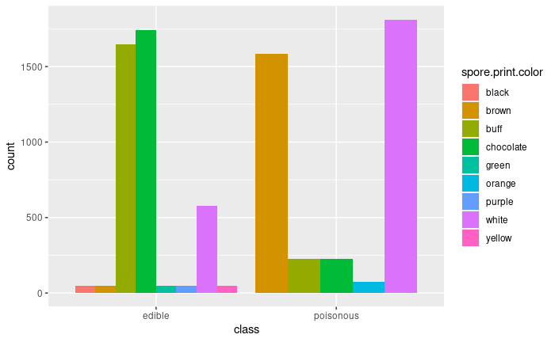

```r
ggplot(mushrooms, aes(class, ..count..)) + geom_bar(aes(fill=spore.print.color), position="dodge")
```

```r
chisq.test(mushrooms$class, mushrooms$spore.print.color)
```

```
    Pearson's Chi-squared test

data:  mushrooms$class and mushrooms$spore.print.color
X-squared = 4602, df = 8, p-value < 2.2e-16
```

```r
# Combining Levels
mushrooms$spore.print.color <- combineLevels(mushrooms$spore.print.color, c("yellow", "black", "orange", "green", "purple"), "other")
```

```
The original levels black brown buff chocolate green orange purple white yellow
have been replaced by brown buff chocolate white other
```

### Class and Population

The Chi-squared test returned a p-value less than a significance level of 0.05 indicating the two variables are associated. The graph also highlights the fact that the majority of poisonous mushrooms are mostly grouped several together, and are not abundant or numerous compared to the edible mushrooms.

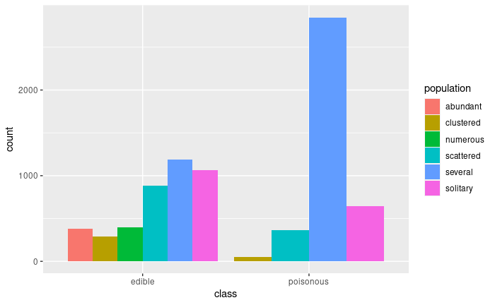

```r
ggplot(mushrooms, aes(class, ..count..)) + geom_bar(aes(fill=population), position="dodge")
```

```r
chisq.test(mushrooms$class, mushrooms$population)
```

```
    Pearson's Chi-squared test

data:  mushrooms$class and mushrooms$population
X-squared = 1929.7, df = 5, p-value < 2.2e-16
```

### Class and Habitat

The Chi-squared test returned a p-value less than a significance level of 0.05 indicating the two variables are associated. The graph also highlights the fact that more poisonous mushrooms are found in urban areas than edible mushrooms as well as being non-existent in woods.

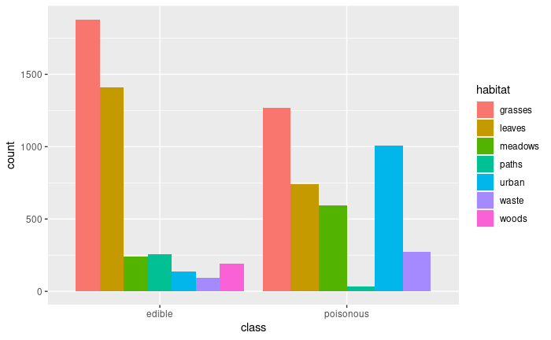

```r
ggplot(mushrooms, aes(class, ..count..)) + geom_bar(aes(fill=habitat), position="dodge")
```

```r
chisq.test(mushrooms$class, mushrooms$habitat)
```

```
    Pearson's Chi-squared test

data:  mushrooms$class and mushrooms$habitat
X-squared = 1573.8, df = 6, p-value < 2.2e-16
```

## Classifying Mushroom Edibility using ML Models

The following models are trained and tested in this section:

- Naive Bayes
- C5.0
- Bagged CART
- Random Forest
- Ada Boost
- Gradient Boost
- Neural Network

### Preprocessing the data

Splitting the data into the training and test set.

```r
library(caret)
in_train <- createDataPartition(mushrooms$class, p = 0.80, list = FALSE)
mushrooms_train <- mushrooms[in_train, ]
mushrooms_test <- mushrooms[-in_train, ]
```

### Naive Bayes

The Naive Bayes model resulted in ~93% accuracy rating. While this seems good the number of false negatives is not good. Kappa ended with a 0.85 which is good. The AUC is ~0.93 which while good is still not good enough considering the consequences of ingesting a misclassified mushroom.

```r
set.seed(1)
# Create the model
naive_bayes_model <- caret::train(class ~ ., data = mushrooms_train,
                           trControl = trainControl(method = "cv", number = 10),
                           method = "naive_bayes",
                           metric = "Accuracy")
print(naive_bayes_model)
```

```
Naive Bayes

6500 samples
  19 predictor
   2 classes: 'edible', 'poisonous'

No pre-processing
Resampling: Cross-Validated (10 fold)
Summary of sample sizes: 5851, 5850, 5849, 5850, 5849, 5851, ...
Resampling results across tuning parameters:

  usekernel  Accuracy   Kappa
  FALSE      0.9343052  0.8683692
   TRUE      0.9264586  0.8521769

Tuning parameter 'laplace' was held constant at a value of 0
Tuning parameter 'adjust' was held constant at a value of 1
Accuracy was used to select the optimal model using the largest value.
The final values used for the model were laplace = 0, usekernel = FALSE and adjust = 1.
```

```r
# Make Predictions
naive_bayes_pred <- predict(naive_bayes_model, mushrooms_test)
# View results
confusionMatrix(naive_bayes_pred, mushrooms_test$class, positive = "edible")
```

```
Confusion Matrix and Statistics

           Reference
Prediction  edible poisonous
  edible       786        70
  poisonous     55       713

               Accuracy : 0.923
                 95% CI : (0.909, 0.9355)
    No Information Rate : 0.5179
    P-Value [Acc > NIR] : <2e-16

                  Kappa : 0.8458

 Mcnemar's Test P-Value : 0.2105

            Sensitivity : 0.9346
            Specificity : 0.9106
         Pos Pred Value : 0.9182
         Neg Pred Value : 0.9284
             Prevalence : 0.5179
         Detection Rate : 0.4840
   Detection Prevalence : 0.5271
      Balanced Accuracy : 0.9226

       'Positive' Class : edible
```

```r
# Top Predictors
varImp(naive_bayes_model)
```

```
ROC curve variable importance
```

|  | Importance |
| --- | --- |
| gill.color | 100.000000 |
| stalk.surface.above.ring | 89.259478 |
| stalk.surface.below.ring | 87.356950 |
| bruises | 81.810518 |
| gill.size | 81.448471 |
| ring.type | 73.459009 |
| gill.spacing | 37.378844 |
| habitat | 35.754847 |
| population | 34.518995 |
| stalk.root | 30.406244 |

[output cut: 9 more lines]

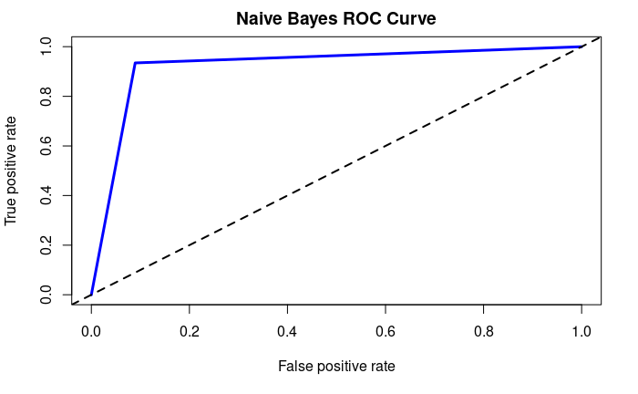

```r
# ROC & AUC
pred <- prediction(as.numeric(naive_bayes_pred == "edible"), as.numeric(mushrooms_test$class == "edible"))
perf <- performance(pred, measure = "tpr", x.measure= "fpr")
plot(perf, main = "Naive Bayes ROC Curve", col = "blue", lwd= 3)
abline(a = 0, b = 1, lwd= 2, lty= 2)
```

```r
unlist(performance(pred, measure = "auc")@y.values)
```

```
[1] 0.922601
```

### C5.0

The c50 model returned an Accuracy and Kappa of 1 meaning it perfectly classified whether the mushrooms is edible or not. The model reported 7 variables that it found to be most useful.

```r
set.seed(1)
# Create the model
c50_model <- caret::train(class ~ ., data = mushrooms_train,
                   trControl = trainControl(method = "cv", number = 10),
                   method = "C5.0",
                   metric = "Accuracy")
```

[output not shown]

```r
print(c50_model)
```

```
C5.0

6500 samples
  19 predictor
   2 classes: 'edible', 'poisonous'

No pre-processing
Resampling: Cross-Validated (10 fold)
Summary of sample sizes: 5851, 5850, 5849, 5850, 5849, 5851, ...
Resampling results across tuning parameters:

  model  winnow  trials  Accuracy  Kappa
  rules  FALSE    1      1         1
  rules  FALSE   10      1         1
  rules  FALSE   20      1         1
  rules   TRUE    1      1         1
  rules   TRUE   10      1         1
  rules   TRUE   20      1         1
  tree   FALSE    1      1         1
  tree   FALSE   10      1         1
  tree   FALSE   20      1         1
  tree    TRUE    1      1         1
  tree    TRUE   10      1         1
  tree    TRUE   20      1         1

Accuracy was used to select the optimal model using the largest value.
The final values used for the model were trials = 1, model = rules and winnow = TRUE.
```

```r
# Make Predictions
c50_pred <- predict(c50_model, mushrooms_test)
# View results
confusionMatrix(c50_pred, mushrooms_test$class, positive = "edible")
```

```
Confusion Matrix and Statistics

           Reference
Prediction  edible poisonous
  edible       841         0
  poisonous      0       783

               Accuracy : 1
                 95% CI : (0.9977, 1)
    No Information Rate : 0.5179
    P-Value [Acc > NIR] : < 2.2e-16

                  Kappa : 1

 Mcnemar's Test P-Value : NA

            Sensitivity : 1.0000
            Specificity : 1.0000
         Pos Pred Value : 1.0000
         Neg Pred Value : 1.0000
             Prevalence : 0.5179
         Detection Rate : 0.5179
   Detection Prevalence : 0.5179
      Balanced Accuracy : 1.0000

       'Positive' Class : edible
```

```r
# Top Predictors
varImp(c50_model)
```

```
C5.0 variable importance

  only 20 most important variables shown (out of 79)
```

|  | Overall |
| --- | --- |
| odormusty | 100.00000 |
| stalk.rootrooted | 71.71571 |
| stalk.rootclub | 56.34647 |
| bruisesfalse | 54.38090 |
| stalk.surface.below.ringother | 49.72793 |
| gill.spacingcrowded | 49.17268 |
| spore.print.colorother | 44.96391 |
| habitatmeadows | 42.99833 |
| cap.coloryellow | 39.00056 |
| cap.colorwhite | 38.77846 |

[output cut: 10 more lines]

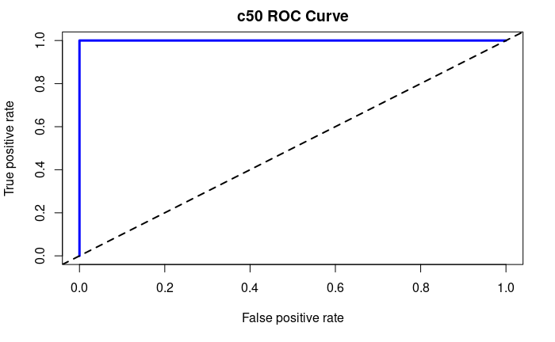

```r
# ROC & AUC
pred <- prediction(as.numeric(c50_pred == "edible"), as.numeric(mushrooms_test$class == "edible"))
perf <- performance(pred, measure = "tpr", x.measure= "fpr")
plot(perf, main = "c50 ROC Curve", col = "blue", lwd= 3)
abline(a = 0, b = 1, lwd= 2, lty= 2)
```

```r
unlist(performance(pred, measure = "auc")@y.values)
```

```
[1] 1
```

### Bagged CART

The bagging model also perfectly predicted the class variable. It also has the odor-musty as the best predictor which the C50 algorithm choose as well.

```r
set.seed(1)
# Create the model
bag_model <- caret::train(class ~ ., data = mushrooms_train,
                   trControl = trainControl(method = "cv", number = 10),
                   method = "treebag",
                   metric = "Accuracy")
print(bag_model)
```

```
Bagged CART

6500 samples
  19 predictor
   2 classes: 'edible', 'poisonous'

No pre-processing
Resampling: Cross-Validated (10 fold)
Summary of sample sizes: 5851, 5850, 5849, 5850, 5849, 5851, ...
Resampling results:

  Accuracy  Kappa
  1         1
```

```r
# Make Predictions
bag_pred <- predict(bag_model, mushrooms_test)
# View results
confusionMatrix(bag_pred, mushrooms_test$class, positive = "edible")
```

```
Confusion Matrix and Statistics

           Reference
Prediction  edible poisonous
  edible       841         0
  poisonous      0       783

               Accuracy : 1
                 95% CI : (0.9977, 1)
    No Information Rate : 0.5179
    P-Value [Acc > NIR] : < 2.2e-16

                  Kappa : 1

 Mcnemar's Test P-Value : NA

            Sensitivity : 1.0000
            Specificity : 1.0000
         Pos Pred Value : 1.0000
         Neg Pred Value : 1.0000
             Prevalence : 0.5179
         Detection Rate : 0.5179
   Detection Prevalence : 0.5179
      Balanced Accuracy : 1.0000

       'Positive' Class : edible
```

```r
# Top Predictors
varImp(bag_model)
```

```
treebag variable importance

  only 20 most important variables shown (out of 79)
```

|  | Overall |
| --- | --- |
| odormusty | 100.000000 |
| ring.typenone | 73.185886 |
| odorcreosote | 73.160945 |
| bruisesfalse | 72.937529 |
| gill.sizenarrow | 52.108898 |
| stalk.rootclub | 35.699601 |
| odorfishy | 30.929001 |
| odornone | 11.161700 |
| stalk.rootequal | 10.727177 |
| populationnumerous | 10.216408 |

[output cut: 10 more lines]

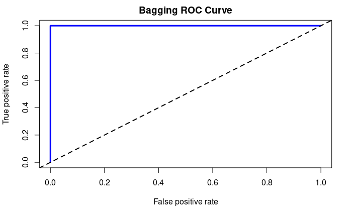

```r
# ROC & AUC
pred <- prediction(as.numeric(bag_pred == "edible"), as.numeric(mushrooms_test$class == "edible"))
perf <- performance(pred, measure = "tpr", x.measure= "fpr")
plot(perf, main = "Bagging ROC Curve", col = "blue", lwd= 3)
abline(a = 0, b = 1, lwd= 2, lty= 2)
```

```r
unlist(performance(pred, measure = "auc")@y.values)
```

```
[1] 1
```

### Random Forest

```r
set.seed(1)
# Create the model
rf_model <- caret::train(class ~ ., data = mushrooms_train,
                   trControl = trainControl(method = "cv", number = 10),
                   method = "rf",
                   metric = "Accuracy")
print(rf_model)
```

```
Random Forest

6500 samples
  19 predictor
   2 classes: 'edible', 'poisonous'

No pre-processing
Resampling: Cross-Validated (10 fold)
Summary of sample sizes: 5851, 5850, 5849, 5850, 5849, 5851, ...
Resampling results across tuning parameters:

  mtry  Accuracy   Kappa
   2    0.9883055  0.9765575
  40    1.0000000  1.0000000
  79    1.0000000  1.0000000

Accuracy was used to select the optimal model using the largest value.
The final value used for the model was mtry = 40.
```

```r
# Make Predictions
rf_pred <- predict(rf_model, mushrooms_test)
# View results
confusionMatrix(rf_pred, mushrooms_test$class, positive = "edible")
```

```
Confusion Matrix and Statistics

           Reference
Prediction  edible poisonous
  edible       841         0
  poisonous      0       783

               Accuracy : 1
                 95% CI : (0.9977, 1)
    No Information Rate : 0.5179
    P-Value [Acc > NIR] : < 2.2e-16

                  Kappa : 1

 Mcnemar's Test P-Value : NA

            Sensitivity : 1.0000
            Specificity : 1.0000
         Pos Pred Value : 1.0000
         Neg Pred Value : 1.0000
             Prevalence : 0.5179
         Detection Rate : 0.5179
   Detection Prevalence : 0.5179
      Balanced Accuracy : 1.0000

       'Positive' Class : edible
```

```r
# Top Predictors
varImp(rf_model)
```

```
rf variable importance

  only 20 most important variables shown (out of 79)
```

|  | Overall |
| --- | --- |
| odormusty | 100.000000 |
| odorcreosote | 40.169233 |
| gill.sizenarrow | 32.117513 |
| bruisesfalse | 14.211597 |
| stalk.rootclub | 11.147055 |
| ring.typenone | 10.844547 |
| odorfishy | 6.040347 |
| gill.spacingcrowded | 5.281224 |
| stalk.rootrooted | 4.424886 |
| ring.typeflaring | 3.759015 |

[output cut: 10 more lines]

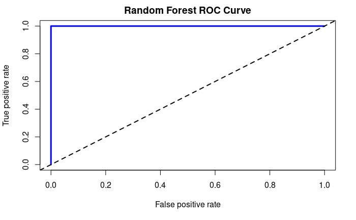

```r
# ROC & AUC
pred <- prediction(as.numeric(rf_pred == "edible"), as.numeric(mushrooms_test$class == "edible"))
perf <- performance(pred, measure = "tpr", x.measure= "fpr")
plot(perf, main = "Random Forest ROC Curve", col = "blue", lwd= 3)
abline(a = 0, b = 1, lwd= 2, lty= 2)
```

```r
unlist(performance(pred, measure = "auc")@y.values)
```

```
[1] 1
```

## Ada Boosting

```r
set.seed(1)
# Create the model
ada_model <- caret::train(class ~ ., data = mushrooms_train,
                   trControl = trainControl(method = "cv", number = 10),
                   method = "adaboost",
                   metric = "Accuracy")
print(ada_model)
```

```
AdaBoost Classification Trees

6500 samples
  19 predictor
   2 classes: 'edible', 'poisonous'

No pre-processing
Resampling: Cross-Validated (10 fold)
Summary of sample sizes: 5851, 5850, 5849, 5850, 5849, 5851, ...
Resampling results across tuning parameters:

  nIter  method         Accuracy   Kappa
   50    Adaboost.M1    0.9989228  0.9978425
   50    Real adaboost  1.0000000  1.0000000
  100    Adaboost.M1    0.9989228  0.9978425
  100    Real adaboost  1.0000000  1.0000000
  150    Adaboost.M1    0.9989228  0.9978425
  150    Real adaboost  1.0000000  1.0000000

Accuracy was used to select the optimal model using the largest value.
The final values used for the model were nIter = 50 and method = Real adaboost.
```

```r
# Make Predictions
ada_pred <- predict(ada_model, mushrooms_test)
# View results
confusionMatrix(ada_pred, mushrooms_test$class, positive = "edible")
```

```
Confusion Matrix and Statistics

           Reference
Prediction  edible poisonous
  edible       841         0
  poisonous      0       783

               Accuracy : 1
                 95% CI : (0.9977, 1)
    No Information Rate : 0.5179
    P-Value [Acc > NIR] : < 2.2e-16

                  Kappa : 1

 Mcnemar's Test P-Value : NA

            Sensitivity : 1.0000
            Specificity : 1.0000
         Pos Pred Value : 1.0000
         Neg Pred Value : 1.0000
             Prevalence : 0.5179
         Detection Rate : 0.5179
   Detection Prevalence : 0.5179
      Balanced Accuracy : 1.0000

       'Positive' Class : edible
```

```r
# Top Predictors
varImp(ada_model)
```

```
ROC curve variable importance
```

|  | Importance |
| --- | --- |
| gill.color | 100.000000 |
| stalk.surface.above.ring | 89.259478 |
| stalk.surface.below.ring | 87.356950 |
| bruises | 81.810518 |
| gill.size | 81.448471 |
| ring.type | 73.459009 |
| gill.spacing | 37.378844 |
| habitat | 35.754847 |
| population | 34.518995 |
| stalk.root | 30.406244 |

[output cut: 9 more lines]

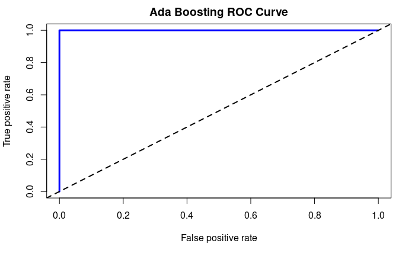

```r
# ROC & AUC
pred <- prediction(as.numeric(ada_pred == "edible"), as.numeric(mushrooms_test$class == "edible"))
perf <- performance(pred, measure = "tpr", x.measure= "fpr")
plot(perf, main = "Ada Boosting ROC Curve", col = "blue", lwd= 3)
abline(a = 0, b = 1, lwd= 2, lty= 2)
```

```r
unlist(performance(pred, measure = "auc")@y.values)
```

```
[1] 1
```

## Gradient Boost

```r
set.seed(1)
# Create the model
grad_model <- caret::train(class ~ ., data = mushrooms_train,
                   trControl = trainControl(method = "cv", number = 10),
                   method = "gbm",
                   metric = "Accuracy",
                   verbose = FALSE)
print(grad_model)
```

```
Stochastic Gradient Boosting

6500 samples
  19 predictor
   2 classes: 'edible', 'poisonous'

No pre-processing
Resampling: Cross-Validated (10 fold)
Summary of sample sizes: 5851, 5850, 5849, 5850, 5849, 5851, ...
Resampling results across tuning parameters:

  interaction.depth  n.trees  Accuracy   Kappa
  1                   50      0.9750769  0.9500728
  1                  100      0.9849226  0.9697955
  1                  150      0.9889216  0.9778057
  2                   50      0.9849233  0.9697867
  2                  100      0.9961536  0.9922946
  2                  150      0.9989228  0.9978425
  3                   50      0.9935387  0.9870530
  3                  100      0.9986147  0.9972252
  3                  150      1.0000000  1.0000000

Tuning parameter 'shrinkage' was held constant at a value of 0.1
Tuning parameter 'n.minobsinnode' was held constant at a
 value of 10
Accuracy was used to select the optimal model using the largest value.
The final values used for the model were n.trees = 150, interaction.depth = 3, shrinkage = 0.1 and n.minobsinnode = 10.
```

```r
# Make Predictions
grad_pred <- predict(grad_model, mushrooms_test)
# View results
confusionMatrix(grad_pred, mushrooms_test$class, positive = "edible")
```

```
Confusion Matrix and Statistics

           Reference
Prediction  edible poisonous
  edible       841         0
  poisonous      0       783

               Accuracy : 1
                 95% CI : (0.9977, 1)
    No Information Rate : 0.5179
    P-Value [Acc > NIR] : < 2.2e-16

                  Kappa : 1

 Mcnemar's Test P-Value : NA

            Sensitivity : 1.0000
            Specificity : 1.0000
         Pos Pred Value : 1.0000
         Neg Pred Value : 1.0000
             Prevalence : 0.5179
         Detection Rate : 0.5179
   Detection Prevalence : 0.5179
      Balanced Accuracy : 1.0000

       'Positive' Class : edible
```

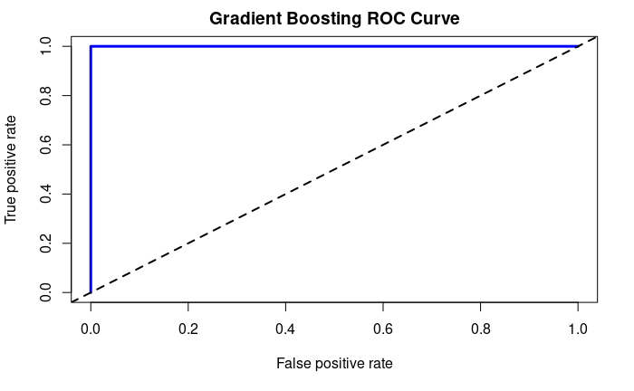

```r
# ROC & AUC
pred <- prediction(as.numeric(grad_pred == "edible"), as.numeric(mushrooms_test$class == "edible"))
perf <- performance(pred, measure = "tpr", x.measure= "fpr")
plot(perf, main = "Gradient Boosting ROC Curve", col = "blue", lwd= 3)
abline(a = 0, b = 1, lwd= 2, lty= 2)
```

```r
unlist(performance(pred, measure = "auc")@y.values)
```

```
[1] 1
```

### Comparing the Results

They basically all performed great except Naive Bayes. It performed the worst of them all, it also had a bunch of false negatives which can not be permitted when it comes to ingesting poisonous mushrooms.

```r
compare <- resamples(list(NB = naive_bayes_model, C = c50_model, B =bag_model, RF = rf_model, A = ada_model, G = grad_model))
summary(compare)
```

```
Call:
summary.resamples(object = compare)

Models: NB, C, B, RF, A, G
Number of resamples: 10

Accuracy
        Min.   1st Qu.    Median      Mean   3rd Qu.      Max. NA's
NB 0.9215385 0.9264809 0.9361572 0.9343052 0.9407692 0.9476923    0
C  1.0000000 1.0000000 1.0000000 1.0000000 1.0000000 1.0000000    0
B  1.0000000 1.0000000 1.0000000 1.0000000 1.0000000 1.0000000    0
RF 1.0000000 1.0000000 1.0000000 1.0000000 1.0000000 1.0000000    0
A  1.0000000 1.0000000 1.0000000 1.0000000 1.0000000 1.0000000    0
G  1.0000000 1.0000000 1.0000000 1.0000000 1.0000000 1.0000000    0

Kappa
        Min.   1st Qu.    Median      Mean   3rd Qu.      Max. NA's
NB 0.8428448 0.8527975 0.8721059 0.8683692 0.8812286 0.8951225    0
C  1.0000000 1.0000000 1.0000000 1.0000000 1.0000000 1.0000000    0
B  1.0000000 1.0000000 1.0000000 1.0000000 1.0000000 1.0000000    0
RF 1.0000000 1.0000000 1.0000000 1.0000000 1.0000000 1.0000000    0
A  1.0000000 1.0000000 1.0000000 1.0000000 1.0000000 1.0000000    0
G  1.0000000 1.0000000 1.0000000 1.0000000 1.0000000 1.0000000    0
```

### Training a Neural Network

Lets create a validation dataset from our training set

```r
val.index <- createDataPartition(mushrooms_train$class, p = 0.80, list = FALSE)
mushrooms_train <- mushrooms_train[val.index, ]
mushrooms_val <- mushrooms_train[-val.index, ]
```

Since all our variables are categorical we will have to one-hot-encode them to put them through a neural network

```r
library(mltools)
library(data.table)
mushrooms_train_one_hot <- one_hot(data.table(mushrooms_train[, -1]))
mushrooms_train_labels <- one_hot(data.table(mushrooms_train$class))
mushrooms_test_one_hot <- one_hot(data.table(mushrooms_test[, -1]))
mushrooms_test_labels <- one_hot(data.table(mushrooms_test$class))
mushrooms_val_one_hot <- one_hot(data.table(mushrooms_val[, -1]))
mushrooms_val_labels <- one_hot(data.table(mushrooms_val$class))
```

```r
library(keras)
model <- keras_model_sequential()
model %>%
  layer_dense(units = 256, input_shape = dim(mushrooms_train_one_hot)[2], activation = 'relu') %>%
  layer_dense(units = 75, activation = 'relu') %>%
  layer_dense(units = 2, activation = 'sigmoid')
```

[output not shown]

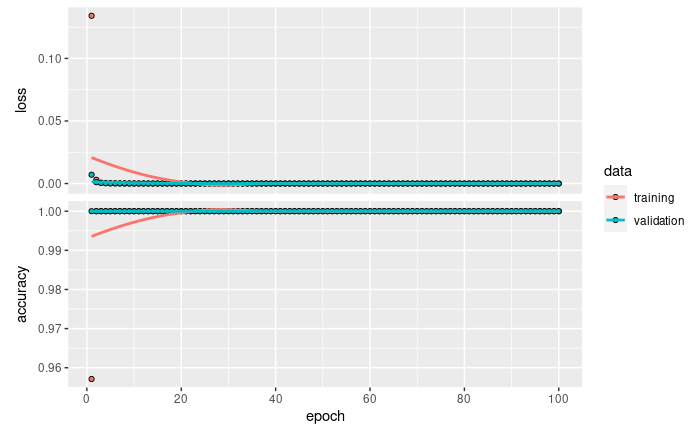

```r
model %>% compile(
  optimizer = 'adam',
  loss = 'categorical_crossentropy',
  metrics = 'accuracy',
)

set.seed(1)
history <- model %>% fit(
  as.matrix(mushrooms_train_one_hot),
  as.matrix(mushrooms_train_labels),
  epochs = 100,
  batch_size = 64,
  verbose = 0,
  validation_data = list(as.matrix(mushrooms_val_one_hot), as.matrix(mushrooms_val_labels)))

plot(history)
```

Let’s evaluate the model. The loss is extremely small and the accuracy is 100%

```r
model %>% evaluate(as.matrix(mushrooms_test_one_hot), as.matrix(mushrooms_test_labels))
```

```
        loss     accuracy
2.129842e-07 1.000000e+00
```

```r
library(tfruns)
set.seed(1)
runs <- tuning_run(
  file = "mushrooms.R",
  flags = list(nodes = c(64, 128, 256),
  learning_rate = c(0.01, 0.05, 0.001, 0.0001),
  batch_size = c(100, 200, 500, 1000),
  epochs = c(30, 50, 100),
  activation = c("relu", "sigmoid", "tanh")),
  sample = 0.02)
```

```
432 total combinations of flags (sampled to 8 combinations)
```